# Unidad 2: Modelo de regresión lineal muestral

Módulo 3: Modelamiento estadístico

Iris Ashimine

# Mínimos Cuadrados Ordinarios: Introducción

Debido a que normalmente contamos con datos muestrales, tenemos que estimar los parámetros poblacionales $\beta$ a partir de la información disponible.

Recordemos el modelo de regresión lineal:
$$y_i=x_i'\beta+e_i$$

donde $y_i$ es una variable aleatoria (escalar), $x_i$ es un vector aleatorio de $K\times 1$ y $e_i$ es una variable aleatoria (escalar).

# Motivación

¿Cuál es el efecto de reducir el tamaño de clase en el rendimiento escolar?

- **Datos**: Todos los distritos escolares de escuelas K-6 y K-8 de California (N=420)[^1].
- **Variables**
  - Notas de examen de 5to grado (Standford-9 achievement test, matemática y lectura), media del distrito *testscr*.
  - Ratio estudiantes por profesor *str*.

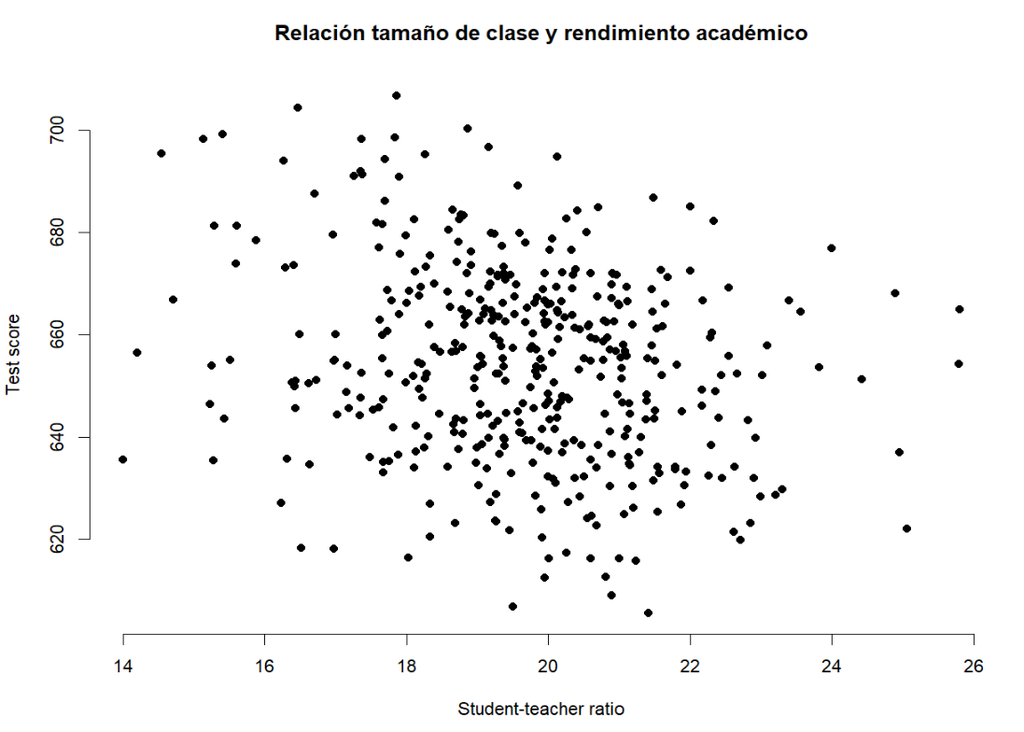

**Modelo**

$$tescr_i=\beta_0+\beta_1str_i+e_i$$
donde $e_i$ contiene todos los factores que influyen sobre el rendimiento escolar además del tamaño de clase.

## Efecto causal

- ¿Mide $\beta_1$ el efecto causal de aumentar el tamaño de clase sobre el rendimiento académico?
- ¿Podemos saber cuál es el efecto de cambiar un estudiante de una clase de 22 estudiantes a una clase de 17 estudiantes?

Para responder esto, necesitamos imponer un supuesto sobre $e_i$.  
Formalmente: $E(e_i|str_i)=0$.

Intuitivamente, no debe haber diferencias en factores que puedan afectar el rendimiento académico en alumnos que asisten a escuelas con distintos tamaño de clase.

- Buscar factores que puedan afectar *el rendimiento académico y el tamaño de clase*.
- Intuir si estos factores *difieren según el tamaño de clase*.

Debido a que es imposible observar un *mismo* estudiante en una clase de 17 y una de 22 alumnos de manera simultánea, ¿podemos comparar reusltados de estudiantes en clases de 17 y 22 alumnos?

¿Bajo qué condiciones esta comparación podría permitir medir el efecto causal?

## Proyecto STAR

Student-Teacher Achievement Ratio[^2] en Tennessee, EUA. El diseño de este proyecto se caracterizó por tres factores principales:

1. Asignación aleatoria de estudiantes y profesores dentro de una misma escuela.
2. Muestra diversa de escuelas (urbanas, rurales, suburbanas).
3. Control de factores externos: nivel socioeconómico, participación de los padres, acceso a recursos, calidad de las instalaciones, apoyo administrativo.

De esta manera se compararon alumnos con variables *observables* similares, pero en clases de distintos tamaños asignadas aleatoriamente. Esto se conoce como **asignación aleatoria condicional en observables**.

$$testscr_i=\beta_0+\beta_1str_i+\gamma'x_i+\epsilon_i$$
donde $x_i$ incluye variables observables como el ingreso, participación de los padres, calidad de instalaciones, etc.
Ahora $\beta_1$ si tiene una interpretación causal.

# Identificación

Para probar que los parámetros estimados mediante MCO son insesgados, son necesarios los siguientes supuestos:

- MCO1 Linealidad en los coeficientes y el término de error
- MCO2 Muestra aleatoria de tamaño N $\rightarrow\{y_i,x_i\}^{N}_{i=1}$ i.i.d[^3].
- MCO3 No correlación entre las variables explicativas y el inobservado[^4]: $E(e_i|x_{1i},x_{2i},...)=E(e_i|x_{2i},x_{3i}...)$}: $E(x_ie_i)=0$.
- MCO4 No colinealidad perfecta entre las variables explicativas: $E(x_i'x_i)$ es invertible.
- MCO5 Condiciones de regularidad para asegurar distribución asintótica normal de los estimadores[^5]: $E(||x_i||^4)<\infty$ y $E(y_i^4)<\infty$.

Bajo estos supuestos se cumple que:

$$\begin{align*}
E(\hat{\beta_1})&=\beta_1, y \\
E(\hat{\beta_0})&=\beta_0
\end{align*}$$

Si queremos escribir los parámetros como una función de momentos poblacionales, ¿qué momentos poblacionales permiten **identificar** los parámetros de interés?

$$\begin{align*}
E(x_ie_i)&=0\; \text{usando MCO2}\\
E[x_i(y_i -x_i'\beta)]&=0 \\
E(x_iy_i)-E(x_i'x_i)\beta&=0 \\
\beta &=E(x_i'x_i)^{-1}E(x_iy_i)\; \text{usando MCO3}
\end{align*}$$

MCO2 y MCO3 son los supuestos que *identifican* $\beta$.

# Estimación

La estimación de los parámetros mediante MCO se puede realizar de dos maneras: mediante el principio de analogía o el método de momentos. Ambos requieren que se cumplan los supuestos establecidos previamente.

## Principio de analogía

Estamos interesados en:

$$\beta_1= E (x_i'x_i)^{-1}E(x_iy_i)$$

Si MCO1 se cumple[^6], entonces podemos estimar la esperanza poblacional mediante la media muestral, es decir, reemplazar momentos poblacionales por momentos muestrales:

$$\hat\beta=\left(\frac{1}{N}\sum_{i=1}^N(x_i'x_i)\right)^{-1}\frac{1}{N}\sum_{i=1}^N(x_i'y_i)$$

## Método de momentos

También podemos hacerlo mediante el método de momentos, debido a que en el modelo poblacional se cumple

$$E[x_i(y_i-x_i'\beta)]=0$$

El estimador satisface una condición similar en la muestra tal que:

$$\frac{1}{N}\sum_{i=1}^Nx_i(y_i-x_i'\beta)=0$$

Despejando $\hat\beta$

$$\hat\beta=\left(\frac{1}{N}\sum_{i=1}^Nx_i'x_i\right)^{-1}\frac{1}{N}\sum_{i=1}^Nx_iy_i$$
donde $X$ es una matriz de $N\times K$ e $Y$ es un vector de $N \times 1$.

# Modelo de regresión simple

Para estimar los parámetros del modelo de regresión más sencillo

$$y_i= \beta_0 +\beta_1 x_{1i}+u_i$$
Los parámetros poblacionales

$$\begin{align*}
\beta_1&=\frac{Cov(x_{1i}y_i)}{Var(x_{1i})}
\beta_0&=E(y_i)-\beta_1E(x_{1i})
\end{align*}$$

El estimador MCO es

$$\begin{align*}
\hat{\beta_1}&=\frac{\hat{Cov}(x_{1i}y_i)}{\hat{Var(x_{1i})}} \\
\hat{\beta_0}&=\frac{1}{N}\sum_{i=1}^{N}y_i-\hat{\beta_1}\frac{1}{N}\sum_{i=1}^{N}x_{1i}
\end{align*}$$

Retomando el ejemplo del tamaño de clase con datos de California. Deseamos estimar el modelo

$$testscr_i=\beta_0+\beta_1str_i+e_i$$
donde supondremos que $E(e_i|str_i)=0$, por tanto

$$E(testscr_i|str_i)=\beta_0+\beta_1str_i$$

donde los parámetros poblacionales tienen una interpretación causal y son calculados mediante

$$\beta_1=\frac{Cov(str_i,testscr_i)}{Var(str_i)},\\
\beta_0=E(testscr_i)-\beta_1E(str_i).$$

Debido a que contamos con una muestra de 420 observaciones, estimaremos mediante **MCO** utilizando el principio de analogía, es decir reemplazando momentos poblacionales por momentos muestrales.

$$\begin{align*}
&\beta_1=\frac{Cov(str_i,testscr_i)}{Var(str_i)} \rightarrow
\hat\beta _1=\frac{\widehat
{Cov}(str_i,testscr_i)}{\widehat{Var}(str_i)} \\
&\beta_0=E(testscr_i)-\beta_1E(str_i)\rightarrow
\hat{\beta_0}=\frac{1}{N}\sum_{i=1}^{N}testscr_i-\hat{\beta}_1\frac{1}{N}\sum_{i=1}^{N}str_i
\end{align*}$$

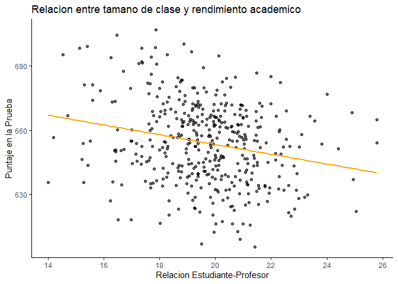

El resultado de la regresión realizada en R

```
## OLS estimation, Dep. Var.: testscr
## Observations: 420
## Standard-errors: IID
##              Estimate Std. Error  t value   Pr(>|t|)
## (Intercept) 698.93295   9.467491 73.82452  < 2.2e-16 ***
## str          -2.27981   0.479826 -4.75133 2.7833e-06 ***
## ---
## Signif. codes:  0 '***' 0.001 '**' 0.01 '*' 0.05 '.' 0.1 ' ' 1
## RMSE: 18.5   Adj. R2: 0.04897
```

# Homocedasticidad

El supuesto de homocedasticidad habla sobre la varianza **condicional** de los errores de regresión $e$, es decir, el segundo momento condicional centrado alrededor del primer momento condicional. La varianza condicional del error se define como:

$$\sigma^2(x)=var[e|X]=E[e^2|x].$$
Es importante recalcar que la varianza condicional es una **función** de los regresores, en cambio la varianza incondicional $\sigma^2$ *por definición* no depende de $X$.

Homocedasticidad es un caso en el que la varianza condicional del error no depende de $X$.

$$\sigma^2(x)=\sigma^2$$
Una idea equivocada es considerar que la homocedasticidad es un componente de una correcta especificación de una regresión y que la heterocedasticidad es una excepción o un error, sin embargo, en la práctica la heterocedasticidad es lo usual, mientras la homocedasticidad es poco usual y excepcional. En todos los trabajos empíricos se debe asumir que los errores son heterocedásticos.

Por otro lado, el supuesto de homocedasticidad se impone también en desarrollos teóricos porque simplifica enormemente los cálculos al momento de estudiar las propiedades de los estimadores.

## Teorema de Gauss-Markov

Si se cumplen los supuestos MCO1 a MCO4 y adicionalmente el supuesto de homocedasticidad $E(e^2|x)=\sigma^2$, entonces el estimador MCO $\hat{\beta}$ es el Mejor Estimador Lineal Insesgado[^7], es decir, tiene la menor varianza (condicional en $X$) entre los estimadores insesgados y lineales.

$$Var[\hat\beta|X]\geq \sigma^2(X'X)^{-1}$$

Este teorema dice que un estimador linear insesgado no puede tener una matriz de varianza meno que $\sigma^2(X'X)^{-1}$, y debido a que (bajo homocedasticidad) la varianza del estimador MCO cumple esta condición con igualdad, es que decimos que es el estimador linear insesgado más eficiente.

# Propiedades algebraicas MCO

- $\sum_{i=1}^N \hat{e_i}=0$
- $\sum_{i=1}^N x_i\hat{e_i}=0$
- $\sum_{i=1}^N\hat{y_i}\hat{e}=0$

La propiedad 1 deriva directamente de la Condición de Primer Orden para derivar $\beta_0$.

Consideremos el modelo simple con intercepto

$$y_i=\beta_0+\beta_1x_i+e_i$$
Obetenemos los estimadores mediante MCO

$$\begin{align*}
&argmin\sum_{i=1}^N(y_i-\hat{\beta_0}-\hat{\beta_1}x_i)^2 \\
&CPO \; de\;\beta_0: \\
&\sum_{i=1}^N(y_i-\hat{\beta_0}-\hat{\beta_1}x_i)=0
\end{align*}$$

y como lo que está dentro del paréntesis es $\hat{e}$, entonces por construcción

$$\sum_{i=1}^N\hat{e}_i=0$$
De manera similar, la propiedad 2 deriva de la CPO de $\beta_1$

$$\sum_{i=1}^Nx_i(y_i-\hat{\beta_0}-\hat{\beta_1}x_i)=0$$
Como lo que está dentro del paréntesis es $\hat{e}_i$, entonces se cumple que

$$\sum_{i=1}^Nx_i\hat{e}_i=0$$

Es decir, que la covarianza (y por tanto también la correlación) entre los residuos y las variables explicatorias siempre es cero.

La tercera propiedad deriva de la anterior debido a que $\hat{y}_i$ es una función linear de las $x_i$por tanto los residuos y los valores ajustados tampoco están correlacionados.

# Modelo de regresión lineal múltiple

Los modelos de regresión lineal múltiple son una extensión del modelo de regresión lineal simple. En estos, el modelo de regresión involucra más de una variable explicativa o independiente.

$$y_i=\beta_0+\beta_1x_1+\beta_2x_2+...+\beta_kx_k+e$$

Estos modelos nos permiten controlar por más de un factor que pueden afectar simultáneamente a la variable dependiente.

**El estimador MCO en forma matricial:**

$$\hat{\beta}=(X'X)^{-1}(X'Y)$$

De la misma manera que el modelo poblacional, para que $\hat\beta$ sea único, se requiere que no exista colinealidad perfecta entre las variables explicativas, en otras palabras, que la matriz ’$(X'X)$ sea invertible.

Adicionalmente, cuando tratamos con múltiples variables explicativas, es fundamental que se cumpla el siguiente supuesto:

$$E(e|x_1,x_2,...,x_k)=0$$
Quiere decir que ninguno de las variables explicativas pueden estar correlacionadas con factores inobservados.

Cuando este supuesto se cumple el OLS es **insesgado**, sin embargo, si alguna variable relevante es omitida de la ecuación, tendremos un sesgo. Por otro lado, añadir una variable irrelevante o sobreespecificar el modelo no genera sesgo en los estimadores, pero sí afecta a la varianza de los demás estimadores OLS porque puede introducir multicolinealidad.

## Sesgo de variable omitida

El sesgo de variable omitida ocurre cuando en el modelo no incluímos una variable relevante, ya sea por falta de datos sobre dicha variable o por error en la especificación del modelo. Esto produce que nuestros estimadores tengan un sesgo, pero en la gran mayoría de los casos se puede conocer el signo de este sesgo.

Tomemos el siguiente modelo de regresión poblacional que mide un efecto causal:

$$y_i=\beta_0+\beta_1x_{1i}+\beta_2x_{2i}+u_i$$

Sin embargo, no podemos observar $x_{2i}$ y estimamos el modelo

$$y_i=\gamma_0+\gamma_1 x_{1i}+\epsilon_i$$

El parámetro $\gamma_1$ se estimaría mediante

$$\hat{\gamma_1}=\frac{Cov(x_{1i},y_i)}{Var(x_{1i})}$$

Sin embargo, $\beta_1\neq\gamma_1$ para ver esto calcuamos:

$$\begin{align*}
\gamma_1&=\frac{Cov(x_{i1},\beta_0+\beta_1x_{1i}+\beta_2x_{2i}+u_i)}{Var(x_{1i})} \\
&=\frac{Cov(x_{1i},\beta_0)+\beta_1Cov(x_{1i},x_{1i})+\beta_2Cov(x_{1i},x_{2i})+Cov(x_{1i},u_i)}{Var(x_{1i})}
\end{align*}$$

Distribuimos el denominador $Var(x_{1i})$ ; y como $Cov(x_{1i},x_{1i})=Var(x_{1i})$ este término se simplifica. Además $Cov(x_{1i},\beta_0)=0$ porque $\beta_0$ es un parámetro y por el supuesto MCO4 $Cov(x_{1i},u_i)=0$ . De tal manera que:

$$\begin{align*}
\gamma_1&=\beta_1+\beta_2\frac{Cov(x_{1i},x_{2i})}{Var(x_{1i})}
\end{align*}$$

En el límite el sesgo asintótico de $\hat{\gamma_1}$:

$$\hat{\gamma}_1-\beta_1=\beta_2\frac{Cov(x_{1i},x_{2i})}{Var(x_{1i})}$$

El signo de este sesgo depende así de dos relaciones: $\beta_2$ o el efecto de la variable omitida sobre la variable independiete y $Cov(x_{1i}, x_{2i})$[^8] o la relación entre la variable independiente incluida y la omitida.

Supongamos que tenemos la regresión poblacional o modelo verdadero que relaciona el ingreso (medido en logaritmos) con los años de educación y la habilidad innata de las personas.

$$lwage_i=\beta_0+\beta_{educ}educ_i+\beta_{abil}abil_i+u_i$$
Sin embargo, debido a que no tenemos como medir la habilidad innata, no contamos con esa variable, por lo tanto esitmamos el siguiente modelo

$$lwage_i=\gamma_0+\gamma_{educ}educ_i+\epsilon_i$$

Entonces nuestro parámetro estimado de educación tendrá un sesgo asintótico medido por

$$\begin{align*}
\hat{\gamma}_{educ}&=\gamma_{educ}-\beta_{educ}\\
&=\beta_{abil}\frac{Cov(educ_i,abil_i)}{Var(educ_i)}
\end{align*}$$

Debido a que podemos defender que la relación entre la habilidad y el salario que gana un individuo es positiva $\beta_{abil}>0$ , y que la relación entre los años de educación y la habilidad también es positiva $Cov(educ_i,abil_i)>0$ entonces el signo del sesgo será también positivo.

En este caso esto significaría un problema, debido a que estaríamos **sobre estimando** el efecto de la educación al utilizar la ecuación “corta”.

[^1]: Esta base de datos corresponde a *CASchools* del paquete AER.
[^2]: Proyecto llevado acabo entre 1985 y 1989, buscaba evaluar los efectos del tamaño de clase sobre el desempeño escolar. Involucraron 6000 estudiantes de 75 escuelas. Sus resultados demostraron que tamaños de clase más pequeños mejoraban significativamente el desempeño de los estudiantes, particularmentente para estudiantes de ingresos bajos y de minoría étnica.
[^3]: Independiente e idénticamente distribuido
[^4]: La versión más debil de este supuesto solo implica **Independencia de Condicional en Media**
[^5]: Conocidas como “No fat tails”, muchas veces ignoradas en la práctica.
[^6]: Este supuesto implica que si tomas dos individuos $i\neq j$ de la muestra, sus valores $(y_i x_i)$ y $(y_j x_j)$ son independientes pero que tienen la misma distribución. Este supuesto se puede romper cuando los individuos de la muestra están conectados de alguna manera, por ejemplo, si son vecinos, miembros de la misma comunidad, compañeros de trabajo. Un enfoque popular que permite la dependencia mutua se conoce como dependencia agrupada, que supone que las observaciones se agrupan en *clusters*.
[^7]: BLUE en inglés.
[^8]: La varianza por definición es siempre positiva.